# Segunda Parte: Informe árboles de regresión

David Rabanedo

## Análisis y composición de los datos a utilizar

```r
datos <- read.table('kc_house_data.csv', header = TRUE, sep =',')
library(rpart)
library(rpart.plot)
library(ranger)
library(ggplot2)
set.seed(732)
```

Vamos en primer lugar a hacer un análisis general de los datos:

- id: Unique ID for each home sold
- date: Date of the home sale
- price: Price of each home sold
- bedrooms: Number of bedrooms
- bathrooms: Number of bathrooms, where .5 accounts for a room with a toilet but no shower
- sqft_living: Square footage of the apartments interior living space
- sqft_lot: Square footage of the land space
- floors: Number of floors
- waterfront: A dummy variable for whether the apartment was overlooking the waterfront or not
- view: An index from 0 to 4 of how good the view of the property was
- condition: An index from 1 to 5 on the condition of the apartment,
- grade: An index from 1 to 13, where 1-3 falls short of building construction and design, 7 has an average level of construction and design, and 11-13 have a high quality level of construction and design.
- sqft_above: The square footage of the interior housing space that is above ground level
- sqft_basement: The square footage of the interior housing space that is below ground level
- yr_built: The year the house was initially built
- yr_renovated: The year of the house’s last renovation
- zipcode: What zipcode area the house is in
- lat: Lattitude
- long: Longitude
- sqft_living15: The square footage of interior housing living space for the nearest 15 neighbors
- sqft_lot15: The square footage of the land lots of the nearest 15 neighbors

```r
#Preparamos los datos para hacer la regresión, aplicamos el logaritmo para eliminar la asimetría y obtener una variable próxima a la normal
#Extraer fecha si me veo con fuerza
datos_sel = datos[c(3,4,5,6,7,8,9,10,11,12,13,14,15,17,20,21)]

datos_sel$log_price = log(datos$price) #Hacer el estudio de las dos

## Convertimos en factor las variables que lo son, las cualitativas:
datos_sel$waterfront = factor(datos_sel$waterfront)
datos_sel$condition = factor(datos_sel$condition)
datos_sel$view = factor(datos_sel$view)
datos_sel$grade = factor(datos_sel$grade)
datos_sel$zipcode = factor(datos_sel$zipcode)
```

Como en este caso, tenemos dos casas cuya extensión es terriblemente grande, destacando sobre las demás, vamos a eliminarlas de cara a que o afecten tanto a la regresión que vamos a realizar a continuación.

```r
aux = datos_sel$sqft_living > 10000
datos_sel = datos_sel[!aux,]
```

## Árbol de regresión total: en busca del mejor parámetro

Realizamos el árbol de regresión, en primer lugar, vamos a hacer el árbol crecido totalmente de cara a poder elegir el mejor parámetro de complejidad posible. Para ello utilizaremos el método que minimiza el x-error y el método 1SE, de cara a compararlos de nuevo.

```r
datos_reg <- rpart(log_price ~ bathrooms + sqft_living + sqft_lot + floors +
                     waterfront + view + condition + grade + sqft_above +
                     sqft_basement + yr_built + zipcode +  sqft_living15 +
                     sqft_lot15, data=datos_sel, cp = 0)
```

Aquí tenemos toda la información, pero lo que a nosotros nos interesa es elegir el mejor parámetro de complejidad (*cp*) para realizar la poda a nuestro árbol. Vamos a ver cuales son los optimos mostrándolos en una tabla. La tabla es demasiado extensa, por lo que vamos a omitir su presentación, pero la usaremos para extraer los valores.

```r
datos_reg$cptable
```

### Método 1SE para obtener el mejor árbol posible

Podemos mirarlo directamente, viendo primero:

$$xerror_k = \min{xerror}$$
Donde
$$xstd_k$$
es el error estándar asociado a ese xerror minímo, en la posición k de la tabla. Queremos entonces encontrar el primer cp que cumple:
$$xerror_{cp} < xerror_k + xstd_k$$
De esta forma encontramos el cp óptimo por el método 1SE.

```r
one_se = datos_reg$cptable[which.min(datos_reg$cptable [,4]),4] + datos_reg$cptable[which.min(datos_reg$cptable [,4]),5]
a = datos_reg$cptable[,4] > one_se
cp_optimo_pos = min(which(a == FALSE))
cp_se = sqrt(datos_reg$cptable[cp_optimo_pos,"CP"]*datos_reg$cptable[cp_optimo_pos-1,"CP"])
cp_se
```

```
## [1] 0.0001135544
```

También podemos aplicar el siguiente comando, que nos muestra la mejor decisión utilizando el método 1SE. Esta decisión se corresponde al primer valor (el que esté mas a la izquierda debajo de la linea horizontal), pero no se aprecia nada.

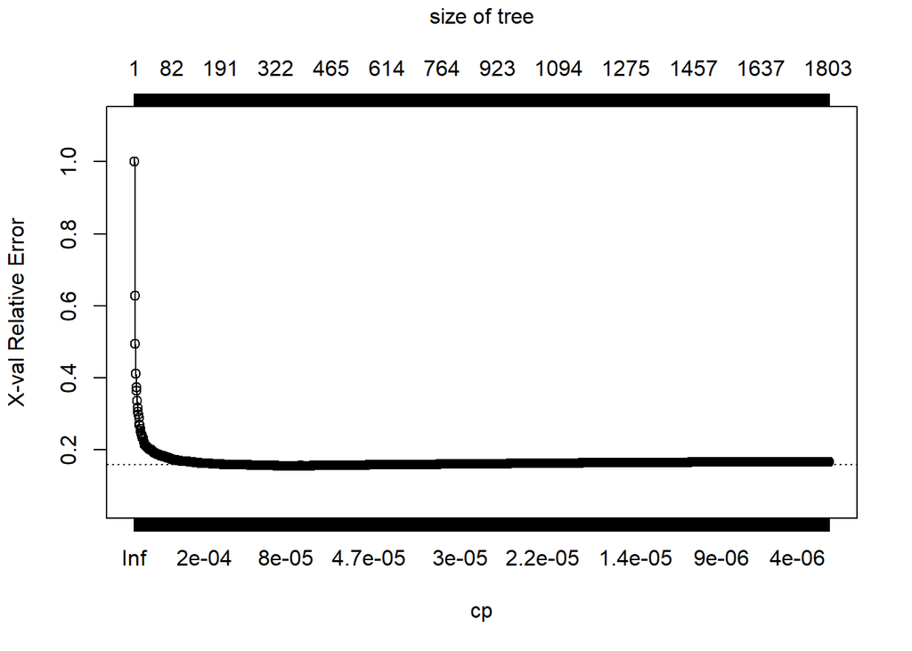

```r
plotcp(datos_reg)
```

#### **Mejor árbol por el método 1SE**

```r
datos_reg_se <- rpart(log_price ~ bathrooms + sqft_living + sqft_lot + floors +
                     waterfront + view + condition + grade + sqft_above +
                     sqft_basement + yr_built + zipcode +  sqft_living15 +
                     sqft_lot15, data=datos_sel, cp = cp_se)
```

### Método minimización del x-error para obtener el mejor árbol posible

Este es más facil de calcular ya que sólo necesitamos hallar el mínimo de la cp_table, pero en este caso seguramente sea tan grande que no nos va a ser útil de cara al calculo, ya que el anterior ya era bastante grande.

```r
cp_xe = datos_reg$cptable[which.min(datos_reg$cptable[,4]),1]
cp_xe
```

```
## [1] 7.931992e-05
```

#### **Mejor árbol por el método de minimización del x-error**

```r
datos_reg_xe <- rpart(log_price ~ bathrooms + sqft_living + sqft_lot + floors +
                     waterfront + view + condition + grade + sqft_above +
                     sqft_basement + yr_built + zipcode +  sqft_living15 +
                     sqft_lot15, data=datos_sel, cp = cp_xe)
```

### Cross-Validation

Para poder calcular el error que cometen estos árboles en la regresión, aplicamos el método de cross-validation, que hay que adaptar los árboles de regresión de cara a hallar bien el error que nos piden

```r
## Primero elegimos el número de capas de cross-validation
fold = 10
## Observaciones
n = 21610
## Tamanño de la muestra test
n_test = n/fold
## Tamaño de la muestra trainning
n_tr = n - n_test
vn = 1:n
```

Ya tenemos todos los datos, vamos ahora a realizar el método de cross-validation para ver que número de observaciones clasifica bien y ver así la eficiencia del árbol que hemos generado.

### Cross-Validation error de la 1SE

Primero lo hacemos con log(price):

```r
#Solo hay que cambiar para hacer la mean - valor calculado.
cv_error = 0
for (i in 1:fold ) {
  i_test = 1:n_test + (i - 1)*n_test
  i_tr = vn[-i_test]
  datos_tr = datos_sel[i_tr,]
  datos_test = datos_sel[i_test,]
  tcar_pruned_eficacia  <- rpart(log_price ~ bathrooms + sqft_living +
                           sqft_lot + floors + sqft_above + sqft_basement + yr_built
                         + sqft_living15 + waterfront + condition + view + grade + zipcode + sqft_lot15, data=datos_sel ,control =
                           rpart.control(xval = 10, minbucket = 1, cp = cp_se ))
  tcar_pruned_pred = predict(tcar_pruned_eficacia, datos_test, type = "vector")
  tcar_pruned_ver =  datos_test$log_price
  for (k in 1:length( tcar_pruned_eficacia)) {
    cv_error = cv_error + (tcar_pruned_pred[k] - tcar_pruned_ver[k])^2
  }
}
cv_error/n
```

```
##            1
## 0.0002110133
```

Ahora lo hacemos con price:

```r
#Solo hay que cambiar para hacer la mean - valor calculado.
cv_error = 0
for (i in 1:fold ) {
  i_test = 1:n_test + (i - 1)*n_test
  i_tr = vn[-i_test]
  datos_tr = datos_sel[i_tr,]
  datos_test = datos_sel[i_test,]
  tcar_pruned_eficacia  <- rpart(price ~ bathrooms + sqft_living +
                           sqft_lot + floors + sqft_above + sqft_basement + yr_built
                         + sqft_living15 + waterfront + condition + view + grade + zipcode + sqft_lot15, data=datos_sel ,control =
                           rpart.control(xval = 10, minbucket = 1, cp = cp_se ))
  tcar_pruned_pred = predict(tcar_pruned_eficacia, datos_test, type = "vector")
  tcar_pruned_ver =  datos_test$log_price
  for (k in 1:length( tcar_pruned_eficacia)) {
    cv_error = cv_error + (tcar_pruned_pred[k] - tcar_pruned_ver[k])^2
  }
}
cv_error/n
```

```
##          1
## 2016556843
```

## Random forest de regresión

```r
n_trees_rf = 1000 #Numero de árboles a utilizar
min_nod_size_rf = 1 #Queremos un fullgrown tree, para reducir el sesgo
r_forest = ranger(
    formula = log_price ~ bathrooms + sqft_living +sqft_lot + floors + sqft_above + sqft_basement +yr_built + sqft_living15 + waterfront + condition + view + grade + zipcode + sqft_lot15,
    data = datos_sel, #Conjunto de datos
    num.trees = n_trees_rf,
    mtry = NULL, #Number of variables to possibly split at in each node, Default
    #is the (rounded down) square root of the number variables.
    importance = "impurity_corrected",
    write.forest = TRUE, #Si guarda el árbol para después predecir con ese árbol
    probability = FALSE,
    min.node.size = min_nod_size_rf, #Queremos un fullgrown tree, para reducir el sesgo
    max.depth = NULL, #NULL nos da crecimiento ilimitado
    replace = TRUE, #La muestra la hace con remplazamiento
    case.weights = NULL, #Para oversamplear ciertos valores
    class.weights = NULL, #Pesos para el outcome
    splitrule = "variance",
    split.select.weights = NULL,
    always.split.variables = NULL, #Para meter esas variables siempre en el
    #split a mayores de las que están en mtry
    regularization.factor = 1,
    keep.inbag = FALSE,
    inbag = NULL, #Manually set observations per tree. List of size num.trees,
    #containing inbag counts for each observation. Can be used for stratified sampling.
    oob.error = TRUE,
    num.threads = NULL,
    save.memory = FALSE, #Memory saving split mode
    verbose = TRUE, #   Show computation status and estimated runtime
    seed = 732,
    dependent.variable.name = NULL) #Name of dependent variable, needed if no formula given)
```

Habiendo hecho esto, sólo nos queda saber cómo de bien funciona. Podríamos haber hecho una training sample y una test sample, pero dado que el propio algoritmo nos proporciona el error cometido sobre las Out-Of-The-Bag Observations, vamos a aprovecharlo y ver como clasifica nuestro random forest nuestro propio conjunto (No hay información privilegiada, luego es legítimo)

```r
r_forest$prediction.error #nos da la mean squared error
```

```
## [1] 0.06929499
```

```r
r_forest$r.squared #nos da R-squared
```

```
## [1] 0.7494845
```

#### **Cálculo con el logaritmo del precio**

```r
n_trees_rf_bucle = c(500,1000,1500,2000,3000) #Numero de árboles a utilizar
mtry_rf_bucle = c(round(0.5*sqrt(14)), round(sqrt(14)), round(2*sqrt(14)))
min_nod_size_rf = 1 #Queremos un fullgrown tree, para reducir el sesgo
tabla_comparacion = data.frame(Splits_por_nodo = rep(NA, length(n_trees_rf_bucle)*length(mtry_rf_bucle)), Numero_arboles = rep(NA,length(n_trees_rf_bucle)*length(mtry_rf_bucle)),
                               Mean_squared = rep(NA,length(n_trees_rf_bucle)*length(mtry_rf_bucle)))
rf_tabla = matrix(rep(NA,length(n_trees_rf_bucle)*length(mtry_rf_bucle)), nrow = length(n_trees_rf_bucle))
k = 0
for (i in 1:length(n_trees_rf_bucle)) {
  for (j in 1:length(mtry_rf_bucle)) {
    n_trees_int = n_trees_rf_bucle[i]
    mtry_int = mtry_rf_bucle[j]
    r_forest_buc = ranger(
      formula = log_price ~ bathrooms + sqft_living +sqft_lot + floors + sqft_above + sqft_basement +yr_built + sqft_living15 + waterfront + condition + view + grade + zipcode + sqft_lot15,
      data           = datos_sel,
      num.trees      = n_trees_int,
      importance     = "impurity_corrected",
      mtry           = mtry_int ,
      seed           = 732,
      splitrule      = "variance")
    rf_tabla[i,j] = r_forest_buc$prediction.error
    k = k + 1
    tabla_comparacion$Mean_squared[k] = r_forest_buc$prediction.error
    tabla_comparacion$Splits_por_nodo[k] = mtry_rf_bucle[j]
    tabla_comparacion$Numero_arboles[k]  = n_trees_rf_bucle[i]

  }
}
tabla_comparacion$Mean_squared = as.factor(tabla_comparacion$Mean_squared)
tabla_comparacion
```

| Splits_por_nodo | Numero_arboles | Mean_squared |
| --- | --- | --- |
| 2 | 500 | 0.0770891203536419 |
| 4 | 500 | 0.0655241300783248 |
| 7 | 500 | 0.0589407559181311 |
| 2 | 1000 | 0.0767215245987323 |
| 4 | 1000 | 0.0652600934918434 |
| 7 | 1000 | 0.0585960091260327 |
| 2 | 1500 | 0.0767441156027658 |
| 4 | 1500 | 0.0651729088629007 |
| 7 | 1500 | 0.0585140978163905 |
| 2 | 2000 | 0.0766610163416018 |
| 4 | 2000 | 0.0651352298972993 |
| 7 | 2000 | 0.0585185062012559 |
| 2 | 3000 | 0.0768339248309148 |
| 4 | 3000 | 0.0650901228651665 |
| 7 | 3000 | 0.0584352830661594 |

Tenemos que el valor que minimiza el error, es aquel que maximiza los aciertos, en este caso:

[output not shown]

Para una mejor interpretación vamos a hacer una gráfica con los diferentes datos:

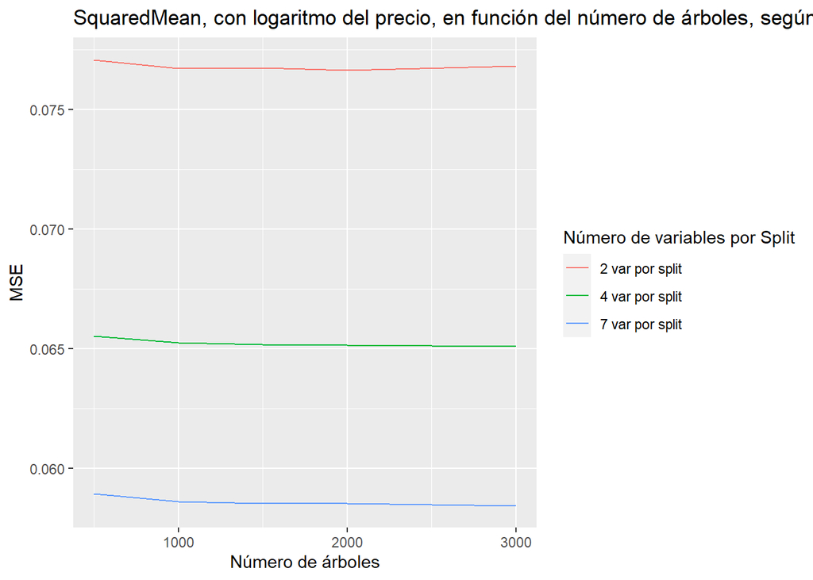

```r
v2_rf = rf_tabla[,1]
v4_rf = rf_tabla[,2]
v7_rf = rf_tabla[,3]
datos_grafica =  data.frame( "Sub" = v2_rf,
                             "Acc" = v4_rf,
                             "Sup" = v7_rf,
                             "Numero_de_arboles" = n_trees_rf_bucle)
ggplot(datos_grafica) +
  geom_line(aes(x = Numero_de_arboles, y = Sub, col = "2 var por split")) +
  geom_line(aes(x = Numero_de_arboles, y = Acc, col = "4 var por split")) +
  geom_line(aes(x = Numero_de_arboles, y = Sup, col = "7 var por split")) +
  scale_color_discrete("Número de variables por Split") +
  labs(title='SquaredMean, con logaritmo del precio, en función del número de árboles, según el split',
       x='Número de árboles',
       y='MSE')
```

#### **Cálculo con price, sin el logaritmo**

```r
n_trees_rf_bucle2 = c(500,1000,1500,2000,3000) #Numero de árboles a utilizar
mtry_rf_bucle2 = c(round(0.5*sqrt(14)), round(sqrt(14)), round(2*sqrt(14)))
min_nod_size_rf2 = 1 #Queremos un fullgrown tree, para reducir el sesgo
tabla_comparacion2 = data.frame(Splits_por_nodo = rep(NA, length(n_trees_rf_bucle2)*length(mtry_rf_bucle2)), Numero_arboles = rep(NA,length(n_trees_rf_bucle2)*length(mtry_rf_bucle2)),
                               Mean_squared = rep(NA,length(n_trees_rf_bucle2)*length(mtry_rf_bucle2)))
rf_tabla2 = matrix(rep(NA,length(n_trees_rf_bucle2)*length(mtry_rf_bucle2)), nrow = length(n_trees_rf_bucle2))
k = 0
for (i in 1:length(n_trees_rf_bucle2)) {
  for (j in 1:length(mtry_rf_bucle2)) {
    n_trees_int2 = n_trees_rf_bucle2[i]
    mtry_int2 = mtry_rf_bucle2[j]
    r_forest_buc2 = ranger(
      formula = price ~ bathrooms + sqft_living +sqft_lot + floors + sqft_above + sqft_basement +yr_built + sqft_living15 + waterfront + condition + view + grade + zipcode + sqft_lot15,
      data           = datos_sel,
      num.trees      = n_trees_int2,
      importance     = "impurity_corrected",
      mtry           = mtry_int2 ,
      seed           = 732,
      splitrule      = "variance")
    rf_tabla2[i,j] = r_forest_buc2$prediction.error
    k = k + 1
    tabla_comparacion2$Mean_squared[k] = r_forest_buc2$prediction.error
    tabla_comparacion2$Splits_por_nodo[k] = mtry_rf_bucle2[j]
    tabla_comparacion2$Numero_arboles[k]  = n_trees_rf_bucle2[i]

  }
}

tabla_comparacion2$Mean_squared = as.factor(tabla_comparacion2$Mean_squared)
tabla_comparacion2
```

[output not shown]

```r
v2_rf2 = rf_tabla2[,1]
v4_rf2 = rf_tabla2[,2]
v7_rf2 = rf_tabla2[,3]
datos_grafica2 =  data.frame( "Sub" = v2_rf2,
                             "Acc" = v4_rf2,
                             "Sup" = v7_rf2,
                             "Numero_de_arboles" = n_trees_rf_bucle)
ggplot(datos_grafica2) +
  geom_line(aes(x = Numero_de_arboles, y = Sub, col = "2 var por split")) +
  geom_line(aes(x = Numero_de_arboles, y = Acc, col = "4 var por split")) +
  geom_line(aes(x = Numero_de_arboles, y = Sup, col = "7 var por split")) +
  scale_color_discrete("Número de variables por Split") +
  labs(title='SquaredMean, con el precio, en función del número de árboles, según el split',
       x='Número de árboles',
       y='MSE')
```

[output not shown]

## Comparación: modelo de regresión

Dado que no tenemos una referencia, vamos a utilizar el modelo de regresión múltiple de cara a poder comparar los resultados obtenidos con el random forest y ver cómo de realmente buenos son las posibles ventajas de este método.

Primero con logaritmo:

```r
mult_reg_log = lm(log_price ~ bathrooms + sqft_living +sqft_lot + floors + sqft_above
              + yr_built + sqft_living15 + sqft_lot15, data=datos_sel)
sum((mult_reg_log$residuals)^2)
```

```
## [1] 2584.468
```

Random forest con logaritmo:

[output not shown]

Ahora sin el logaritmo:

```r
mult_reg_nolog = lm(price ~ bathrooms + sqft_living +sqft_lot + floors + sqft_above
              + yr_built + sqft_living15 + sqft_lot15, data=datos_sel)
sum((mult_reg_nolog$residuals)^2)
```

```
## [1] 1.266828e+15
```